# Oferta, preus i característiques de les veles de Windsurf

Anàlisi de Dades. Repàs 1er parcial

Autor/a

Gerard Ribas Acebes

Publicat

13 de novembre de 2024

[Enllaç al repositori git](https://github.com/gerardet46/Entrega_Parcial_AD/).

# Resum

L’objectiu del treball és estudiar l’oferta de diferents tipus de veles de windsurf en el mercat, així com relacionar les seves especificacions amb el preu final de la vela. Per això, es simularà una mostra aleatòria i s’utilitzaran tècniques d’anàlisi inferencial (com regressió múltiple i contrasts de mitjanes) per donar resposta a quines característiques s’han de tenir en compte a l’hora de comprar una vela en termes de preu i del tipus de navegació. Aquesta anàlisi és important, idò les veles són molt cares i tenen moltes característiques diferents que donaran lloc a millor rendiment i durabilitat en funció del nivell del windsurfista i les condicions de vent. Per tant, és una decisió que involucra una compra relativament alta (tenint en compte que només s’estudia la vela, però és necessita més material: taula, botavara, …) i és millor pensar-s’ho dues vegades abans de comprar nou material.

# Plantejament del problema

El material nàutic i la seva adquisició és complex, ja que sol ser car i amb moltes característiques importants a tenir en compte. Per això, cal tenir bons coneixements i assessorament a l’hora d’adquirir nou material de windsurf. En aquest estudi ens centram només en la vela (una de les moltes parts del windsurf), en concret estudiarem la relació de les diferents característiques amb el preu. També, s’estudiaran les especificacions de les veles disponibles en les dades d’estudi per determinar l’oferta de cada tipus de vela, com per exemple per saber si es venen més veles reforçades o no.

D’aquestes característiques n’estudiam la superfície, l’alçada (*gràtil*), l’amplada (*botavara*), el preu i altres variables d’interès com ara la marca, el material de fabricació, la gama (qualitat general de la vela) i el nombre de politges i el reforç.

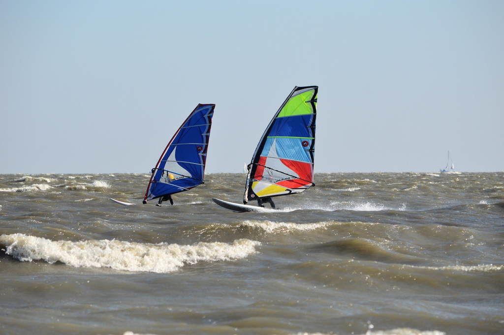

Windsurfs amb veles de PVC. Imatge de domini públic [(enllaç)](https://www.publicdomainpictures.net/en/view-image.php?image=133362)

Les metodologies que emprarem al llarg del treball són l’anàlisi descriptiu i inferencial multivariant, incloent la modelització com una multinomial, la regressió lineal múltiple i la comparació de mitjanes multivariant.

### Simulació de les dades

Les dades amb què treballarem seran simulades. Agafarem una mostra de 150 veles amb nou variables diferents: quatre quantitatives, tres ordinals i dues nominals.

```r
mitj <- c(6.5, 450, 185, 770)
covariances <- matrix(c( 4,  54,  24,    60,
                        54, 900, 270,   600,
                        24, 270, 225,   600,
                        60, 600, 600, 10000), nrow = 4)

set.seed(13112024)
n <- 150
dades_quant <- mvrnorm(n, mu = mitj, Sigma = covariances)
dades_quant[,1] <- pmin(pmax(round(dades_quant[,1], 1), 2.5), 12.5)
dades_quant[,2] <- pmin(pmax(round(dades_quant[,2]), 300), 500)
dades_quant[,3] <- pmin(pmax(round(dades_quant[,3]), 130), 250)
dades_quant[,4] <- pmax(round(dades_quant[,4], 2), 200)

veles <- data.frame(
    m2       = round(dades_quant[,1], 1),
    gratil   = round(dades_quant[,2]),
    botavara = round(dades_quant[,3]),
    preu     = round(dades_quant[,4], 2),
    gama     = ordered(sample(1:3, 150, replace = TRUE), labels = c("Baixa", "Mitjana", "Alta")),
    politges = ordered(sample(1:3, 150, replace = TRUE), labels = c(2,3,4)),
    reforç   = ordered(sample(1:3, 150, replace = TRUE), labels = c("Cap", "Finestra", "Vela")),
    material = ordered(sample(1:2, 150, replace = TRUE), labels = c("PVC", "Monofilm")),
    marca    = ordered(sample(1:3, 150, replace = TRUE), labels = c("Neil Pryde", "Gaastra", "North"))
)
veles %>% glimpse
```

```
Rows: 150
Columns: 9
$ m2       <dbl> 9.1, 2.5, 7.1, 5.2, 6.7, 9.8, 6.0, 6.3, 8.3, 5.8, 6.5, 5.7, 7…
$ gratil   <dbl> 497, 421, 448, 443, 453, 488, 451, 447, 491, 446, 459, 428, 4…
$ botavara <dbl> 189, 142, 197, 180, 177, 220, 180, 189, 191, 174, 186, 196, 1…
$ preu     <dbl> 803.67, 603.78, 756.64, 907.61, 791.65, 836.62, 817.02, 683.5…
$ gama     <ord> Mitjana, Mitjana, Alta, Mitjana, Alta, Baixa, Baixa, Mitjana,…
$ politges <ord> 2, 3, 4, 4, 2, 3, 2, 2, 4, 3, 2, 3, 3, 2, 3, 3, 3, 4, 3, 3, 2…
$ reforç   <ord> Finestra, Finestra, Finestra, Vela, Vela, Cap, Vela, Finestra…
$ material <ord> Monofilm, PVC, PVC, Monofilm, PVC, PVC, PVC, PVC, PVC, PVC, M…
$ marca    <ord> North, Gaastra, Gaastra, Gaastra, Neil Pryde, Neil Pryde, Nor…
```

El significat de cadascuna de les variables és el següent:

- `m2`: la superfície de la vela en metres quadrats. Té mitjana 6.5m², desviació típica 2m² i pren tots els valors entre 2.5m² i 12.5m² amb un decimal de precisió.
- `gratil`: la longitud del gràtil en centímetres, és a dir, la longitud des de la part inferior fins la superior seguint la corba que descriu la vela. Té mitjana 450cm, desviació típica 30cm i pren valors enters entre 300cm i 500cm.
- `botavara`: la longitud de la botavara, és a dir, l’amplada. Té mitjana 185cm, desviació típica 15cm i pren valors enters entre 130cm i 250cm.
- `preu`: el preu de la vela en euros. Pot prendre qualsevol valor (arrodonit a dos decimals) a partir de 200, essent la mitjana un preu de 770€ i desviació típica 100€.
- `politges`: el nombre de politges que disposa al peu de la vela per tensar-la. Les veles tenen entre 2 i 4 politges. És una variable ordinal.
- `reforç`: indica el nivell de reforç de la vela. Pot ser `Cap` (sense reforç), `Finestra` (amb reforç només a la finestra de la vela) i `Vela` (vela completament reforçada). La finestra de la vela és una franja horitzontal situada a l’alçada de la botavara, en el cas de la figura és la franja vermella de la vela multicolor. És una variable ordinal, idò indica el nivell de reforçament de la vela.
- `material`: poden estar fabricades amb PVC o amb Monofilm. És clarament nominal.
- `marca`: restringim l’estudi a només tres marques (de les més utilitzades en el mercat). Tenim *Neil Pryde*, *Gaastra* i *North*. Òbviament es tracta d’una variable nominal.

Cal remarcar que podria semblar que la superfície queda completament determinada pel gràtil i la botavara. Emperò, no és veritat, ja que depèn de la forma de la vela. Anàlogament, l’alçada de la vela no ens revela la botavara ni viceversa: hi ha veles més estretes que altres. Això sí, aquestes tres variables estan molt correlacionades dues a dues, idò major superfície implica major alçada i botavara.

El preu no és tan clar. Com més grossa és la vela més cara és, però hi ha altres factors a tenir en compte com el tipus de vela, el material, la marca i el reforç.

A la simulació, s’han procurat ajustar les covariances per simular el comportament dit abans. Això sí, per simplicitat, la simulació de les variables no quantitatives sí que ha estat completament independent.

# Anàlisi descriptiva

### Paràmetres mostrals

Mostrem la mitjana, la matriu de covariances i la matriu de correlacions de les variables quantitatives.

```r
X <- veles %>% dplyr::select(1:4)
colMeans(X)
```

```
        m2     gratil   botavara       preu
  6.549333 450.393333 185.233333 766.423533
```

```r
cov(X)
```

```
                m2    gratil  botavara        preu
m2        3.654463  50.55026  22.03338    62.40701
gratil   50.550264 825.89123 275.22975   685.68894
botavara 22.033378 275.22975 192.07271   549.49132
preu     62.407012 685.68894 549.49132 10190.63244
```

```r
cor(X)
```

```
                m2    gratil  botavara      preu
m2       1.0000000 0.9201322 0.8316422 0.3233859
gratil   0.9201322 1.0000000 0.6910367 0.2363552
botavara 0.8316422 0.6910367 1.0000000 0.3927602
preu     0.3233859 0.2363552 0.3927602 1.0000000
```

Com era d’esperar, les mitjanes són parescudes a les mitjanes imposades a la simulació, ben igual que la matriu de covariances. Respecte la matriu de correlacions, notem que les parelles superfície-gràtil-botavara estan molt correlacionades mentre que no ho estan tant amb el preu. Emperò, totes són positives, és a dir, a més superfície, major gràtil, botavara i també cost (tot i que en menys pes).

### Matriu de gràfics de dispersió

A continuació, mostram un gràfic de dispersió de les variables quantitatives junt amb el material de fabricació, per tal de mostrar un resum de les dades utilitzades.

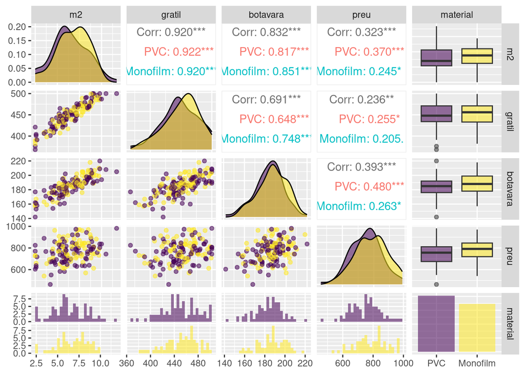

```r
ggpairs(veles %>% dplyr::select(c(1:4, 8)), aes(colour = material, alpha = 0.8))
```

Les correlacions es poden apreciar també en els gràfics de dispersió: les parelles superfície-gràtil-botavara estan més correlacionades i es veu una dispersió més lineal, mentre que amb el preu no passa. També es pot apreciar que les variables quantitatives presenten densitats clarament normals amb les mitjanes que hem imposat a la simulació.

### Variança total i variança generalitzada

Per acabar amb l’anàlisi exploratòria, calcularem la variança total i la generalitzada i interpretarem els resultats en el context del problema.

```r
S <- cov(X) * (n-1) / n
vaps <- eigen(S)$values
VT <- sum(vaps)
VG <- prod(vaps)
VT
```

```
[1] 11137.5
```

```r
VG
```

```
[1] 201512817
```

En aquest cas, la variança generalitzada (recordem que té en compte la interacció entre les variables) és clarament superior a la variança total (només és la suma de variances, no té en compte la interacció). Aleshores, concloem que no hi ha redundància en les dades, idò al considerar la interacció obtenim més variança que si no la consideram.

# Anàlisi inferencial

### El reforçament com una multinomial

Seleccionam la variable `reforç` del conjunt de dades i la modelam amb una multinomial. El reforçament és un factor important a tenir en compte per al preu de la vela, idò implica afegir a sobre de la vela un trenat addicional. A més, en certes modalitats de windsurf (com el *freestyle*) és clau el reforçament de la vela per garantir major durabilitat, mentre que en altres modalitats no és tan important.

Per començar, calcularem els estimadors de màxima versemblança de les proporcions; que sabem que són les proporcions mostrals.

```r
freq <- table(as.data.frame(veles[,7]))
prop <- freq / n
prop
```

```
veles[, 7]
      Cap  Finestra      Vela
0.3733333 0.3333333 0.2933333
```

Així, en una mostra de la variable ens dona un vector indicant el nombre de veles sense reforç, amb reforç només a la finestra i reforçada totalment, en aquest ordre.

Ara, ens interessa la probabilitat que en una mostra de 20 veles hagi més veles reforçades completament que només la finestra, i alhora que hagi més veles amb només la finestra reforçada que no reforçades. Això ens pot ser d’utilitat, per exemple, per saber si en el mercat hi ha molta més oferta de veles reforçades que no reforçades.

Procedirem de dues maneres. La primera, simulant mostres aleatòries de la multinomial i comprovant a quantes se compleix la condició desitaja

```r
nsim <- 3000
set.seed(1714)
sim <- rmultinom(nsim, 20, prop)
# cap reforç <= reforç finestra <= reforç total
sum((sim[1,] <= sim[2,]) & (sim[2,] <= sim[3,])) / nsim
```

```
[1] 0.133
```

Ara, podem calcular-ho també a mà amb la fórmula exacte. Això és, la probabilitat que es doni una mostra fixada per totes les mostres d’interès (i.e. que compleixin la condició donada), i sumant totes les possibilitats

```r
# Sumant totes les probabilitats
# tots els possibles vectors (x1,x2,x3) tq x1 <= x2 <= x3
probabilitat <- 0
# iteram tots els possibles valors
for (cap in seq(0,10)) {
  for (finestra in seq(cap, 20 - cap)) {
    vela <- 20 - finestra - cap
    if (vela >= finestra)  # comprovam que volguem ponderar aquesta probabilitat
      probabilitat <- probabilitat + dmultinom(c(cap, finestra, vela), 20, prob = prop)
  }
}
probabilitat
```

```
[1] 0.1292642
```

En ambdós casos les probabilitats són molt properes. En conclusió, els windsurfistes de *freestyle* se decebran, idò no tendran tantes veles reforçades totalment en proporció a les reforçades només a la finestra i en proporció a les que no tenen reforç.

### Regressió múltiple per explicar el preu

A continuació veurem si se pot explicar el preu a partir de la superfície, el gràtil i la botavara amb un model de regressió múltiple. Això pot ser d’utilitat per tenir en compte si el preu varia de manera lineal significativament si les dimensions de la vela varien.

```r
model <- summary(lm(preu ~ m2+gratil+botavara, data = veles))
model
```

```
Call:
lm(formula = preu ~ m2 + gratil + botavara, data = veles)

Residuals:
    Min      1Q  Median      3Q     Max
-245.75  -59.16   -0.16   61.99  231.79

Coefficients:
            Estimate Std. Error t value Pr(>|t|)
(Intercept) 580.5308   345.7539   1.679   0.0953 .
m2           13.1573    14.1498   0.930   0.3540
gratil       -0.8144     0.7231  -1.126   0.2619
botavara      2.5185     1.0574   2.382   0.0185 *
---
Signif. codes:  0 '***' 0.001 '**' 0.01 '*' 0.05 '.' 0.1 ' ' 1

Residual standard error: 93.38 on 146 degrees of freedom
Multiple R-squared:  0.1616,    Adjusted R-squared:  0.1444
F-statistic: 9.379 on 3 and 146 DF,  p-value: 1.042e-05
```

Notem que hem obtingut coeficients que no són significatius. En particular, la superfície és la que té el p-valor més alt (i per tant no és significatiu per explicar el preu). Per tant, eliminem la superfície i tornem a construir el model.

```r
summary(lm(preu ~ gratil+botavara, data = veles))
```

```
Call:
lm(formula = preu ~ gratil + botavara, data = veles)

Residuals:
     Min       1Q   Median       3Q      Max
-252.998  -60.634   -3.958   61.009  229.896

Coefficients:
            Estimate Std. Error t value Pr(>|t|)
(Intercept) 280.0935   123.0367   2.277   0.0243 *
gratil       -0.2357     0.3681  -0.640   0.5230
botavara      3.1986     0.7633   4.190 4.78e-05 ***
---
Signif. codes:  0 '***' 0.001 '**' 0.01 '*' 0.05 '.' 0.1 ' ' 1

Residual standard error: 93.34 on 147 degrees of freedom
Multiple R-squared:  0.1566,    Adjusted R-squared:  0.1451
F-statistic: 13.65 on 2 and 147 DF,  p-value: 3.656e-06
```

Hem obtingut que el gràtil tampoc és significatiu. Per tant, l’eliminam i ara consideram la regressió del preu en funció només de la botavara.

```r
summary(lm(preu ~ botavara, data = veles))
```

```
Call:
lm(formula = preu ~ botavara, data = veles)

Residuals:
    Min      1Q  Median      3Q     Max
-254.01  -58.67   -5.35   63.91  231.51

Coefficients:
            Estimate Std. Error t value Pr(>|t|)
(Intercept) 236.4986   102.2771   2.312   0.0221 *
botavara      2.8609     0.5506   5.196 6.65e-07 ***
---
Signif. codes:  0 '***' 0.001 '**' 0.01 '*' 0.05 '.' 0.1 ' ' 1

Residual standard error: 93.15 on 148 degrees of freedom
Multiple R-squared:  0.1543,    Adjusted R-squared:  0.1485
F-statistic: 26.99 on 1 and 148 DF,  p-value: 6.65e-07
```

En aquesta ocasió sí que hem obtingut valors significatius per la botavara i l’ordenada a l’origen. Aquest resultat pot ser a causa de l’alta correlació entre la superfície, la botavara i el gràtil, provocant que només una sigui suficient per explicar el preu. Ara bé, notem que, tot i això, el valor de $R^2$ ajustat no és molt alt i, per tant, podem dir que el model de regressió no és adequat per determinar el preu.

De fet, el següent gràfic de dispersió mostra que el model no s’ajusta del tot.

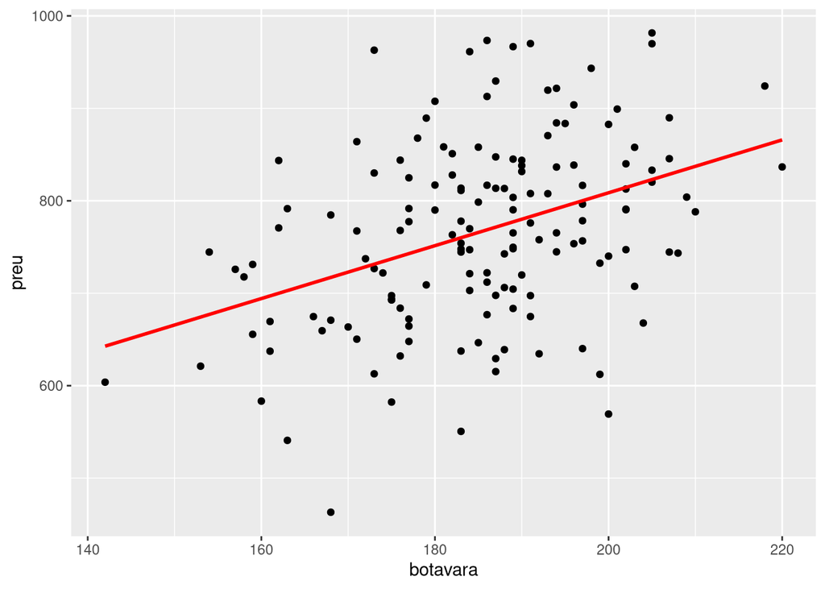

```r
data_lm <- data.frame(botavara = veles$botavara, preu = veles$preu)
ggplot(data_lm, aes(x=botavara, y=preu)) +
  geom_point() +
  geom_smooth(method=lm , color="red", se=FALSE)
```

Ara, calculem la funció d’score al model. Ho farem al primer model considerat, és a dir, el preu en funció de les tres dimensions. Sabem que la funció d’score del model de regressió múltiple és

$$Score(\beta) = \frac{1}{\sigma^2}X^T (Y-X \beta)$$

on $X$ és una columna de uns seguit de les columnes de les tres dimensions, $\beta$ és el vector dels coeficients del model (començant per l’intercepte) i $Y$ és la variable que volem explicar, és a dir, el preu. A més, $\sigma^2$ és la variança de la variable aleatòria $\varepsilon$ que proporciona l’error. L’estimador de màxima versemblança de $\sigma^2$ és la variança dels residuals del model. Aleshores, implementem la funció d’score i calculem-la en aquest cas.

```r
score <- function(X, Y, beta, sigma2) {
  return(t(X) %*% (Y-X%*%beta)) / sigma2
}

X      <- as.matrix(cbind(1, veles[,1:3]))
Y      <- as.matrix(veles %>% dplyr::select(preu))
beta   <- model$coefficients[,1]
sigma2 <- model$sigma ^ 2
score(X, Y, beta, sigma2)
```

```
                 preu
1        3.569767e-11
m2       2.355591e-10
gratil   1.611261e-08
botavara 6.537448e-09
```

Notem que les components de l’score són molt properes a zero, és a dir, el model ha aconseguit arribar a pràcticament el màxim de versemblança. Per tant, aquests coeficients maximitzen la probabilitat d’haver observat les dades del preus en terme de les tres dimensions. Emperò, recordem que hem obtingut que hi ha coeficients que no són significatius i, per tant, el model de regressió lineal no és adequat per explicar el preu.

### Contrast d’hipòtesi de dues mitjanes multivariants (en funció del material de fabricació)

En aquesta secció estudiarem si hi ha diferències significatives en les mitjanes del preu i les dimensions en funció del material de fabricació.

Separam les dades en funció del material, és a dir, si la vela és de monofilm o de PVC.

```r
X1 <- veles %>% filter(material == "Monofilm") %>% dplyr::select(1:4)
X2 <- veles %>% filter(material == "PVC")      %>% dplyr::select(1:4)
```

Les dues mostres provenen d’una normal multivariant (ja que les hem simulades així) i les variances són les mateixes ja que les variables quantitatives i el material les hem generades de manera independent. Primer, desenvoluparem amb tots els càlculs el test $T^2$ de Hotelling. Sabem que l’estadístic de contrast distribueix una F de Fisher amb $p$ i $n_1+n_2-1-p$ graus de llibertat, on $n_1$ i $n_2$ són el nombre de les mostres $X_1$ i $X_2$, respectivament, i $p = 4$ el nombre de variables quantitatives.

```r
p  <- 4
n1 <- nrow(X1)
n2 <- nrow(X2)

# mitjanes mostrals i la seva diferència
mu1 <- colMeans(X1)
mu2 <- colMeans(X2)
mu_diff <- matrix(mu1-mu2, ncol = 1)

# cov ens dona no esbiaixat, hem de multiplicar per ni-1 i no per ni
S      <- ((n1-1)*cov(X1) + (n2-1)*cov(X2)) / (n1+n2-2)
Sinv   <- solve(S)

factor <- (n1+n2-1-p) / ((n1+n2-2)*p) * (n1*n2) / (n1+n2)
estadisticF <- factor * (t(mu_diff) %*% Sinv %*% mu_diff)
estadisticF
```

```
         [,1]
[1,] 1.422861
```

```r
# finalment calculam el p-valor
1-pf(estadisticF, p, n1+n2-1-p)
```

```
          [,1]
[1,] 0.2293108
```

Comprovem que ens dona el mateix resultat que el test implementat en R amb la funció `hotelling.test` del paquet `Hotelling`.

```r
fit <- hotelling.test(X1, X2, var.equal = T)
fit
```

```
Test stat:  5.8092
Numerator df:  4
Denominator df:  145
P-value:  0.2293
```

Aleshores, amb un nivell de significació $\alpha=0.05$, no podem rebutjar que les mitjanes de preu i de dimensions entre els diferents materials siguin iguals.

# Conclusions

En aquest treball hem estudiat les característiques de les veles de windsurf, i també la relació que tenen amb el preu. En primer lloc, s’ha plantejat el problema en el seu context, s’han simulat les dades i s’ha dut a terme una anàlisi exploratòria. En particular, s’ha estudiat les mitjanes i les covariances de les variables, així com la variança total i generalitzada, concloent que no havia redundància a les dades.

En segon lloc, hem emprat eines d’anàlisi inferencial multivariant per inferir resultats a la població total. Els resultats obtinguts són que la probabilitat de trobar-se més oferta de veles reforçades completament que només a la finestra i alhora sense reforçament és baixa (devers 0.13), que pot ser d’interès segons el tipus de windsurfista per conèixer les diferents opcions en funció del reforçament.

També, s’ha provat d’ajustar el preu com a funció lineal de les dimensions de la vela, obtenint que només una de les dimensions és significativa (la botavara). Tot i això, hem conclòs que el model no és adequat ja que presenta un coeficient $R^2$ molt baix.

# Bibliografia

[1] Apunts de l’assignatura *Anàlisi de Dades* de la UIB. https://aprender-uib.github.io/AD/

[2] Apunts de regressió lineal simple i múltiple pujats al curs de [1].

[3] Marques de veles de windsurf. https://www.surfertoday.com/windsurfing/the-best-windsurfing-manufacturers-in-the-world